# Testing Final

UDEP Project, Brigham Young University

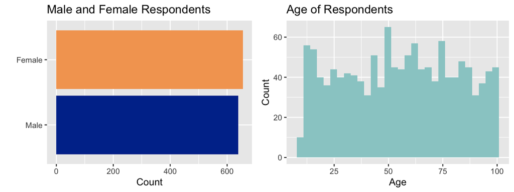

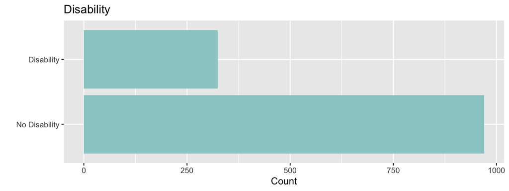

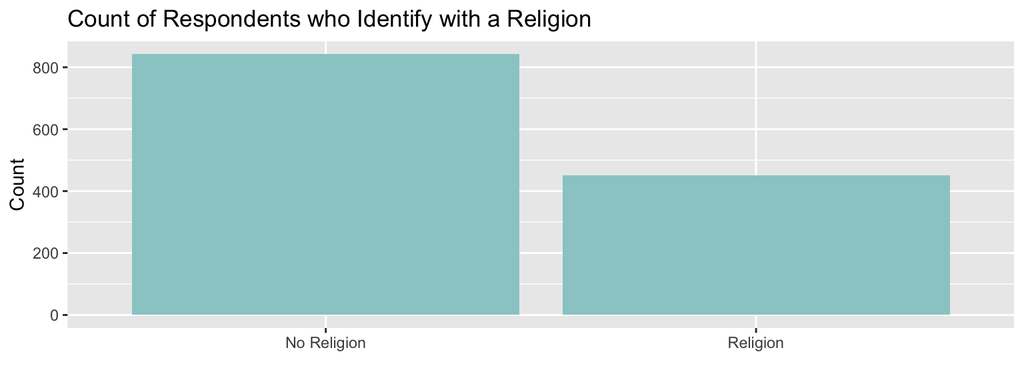

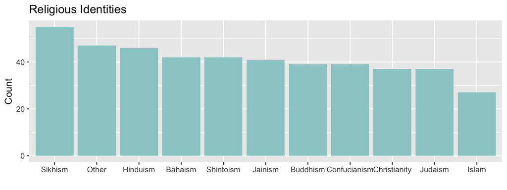

# 1. Poverty

## Income

The overall average income per day is $4.48.

The average income per day for men is $4.42, and the average income per day for women is $4.53. However, the difference is not significant.

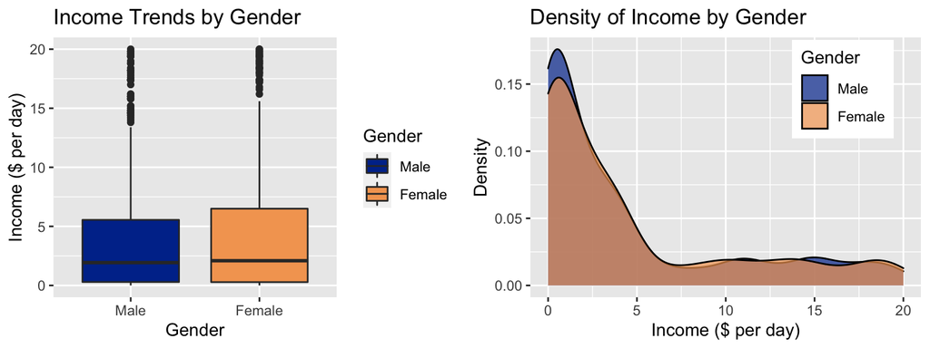

The average income per day for the population ages 0 to 40 is $4.46, and the average income per day for adults is $ 4.49. However, the difference is not significant.

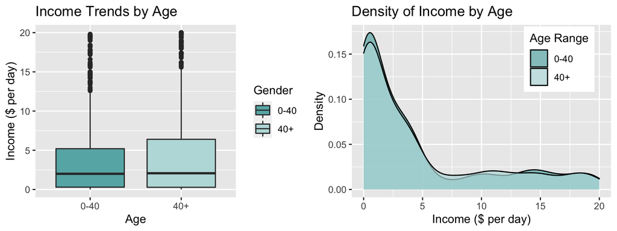

## Access to Facilities

In this sample, 49.15% of the participants have access to electricity or energy, 49.3% of the participants have access to water and sanitation, and 47.14% of the participants have access to refuse and waste removal.

## Land Ownership

Additionally, 11.51% of the participants who indicated they own land also have legal documentation that proves the land ownership. 11% of men and 12% of women in this smaller sample have the legal documentation. However, the difference in legal documentation given land ownership between men and women is not significant.

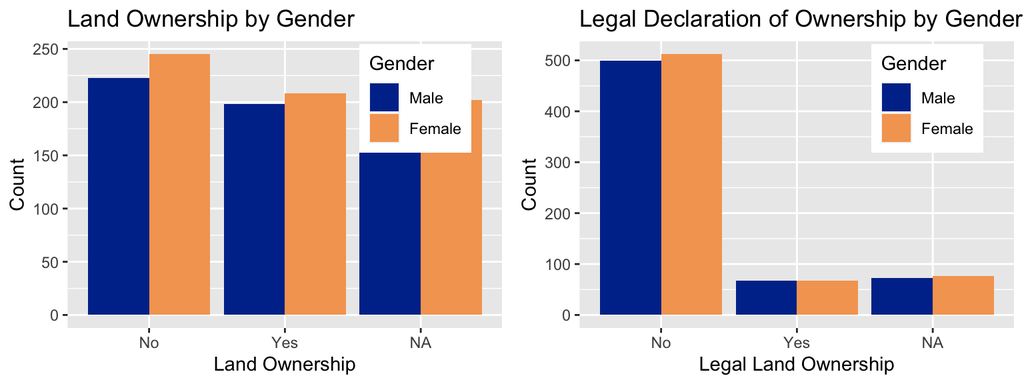

## Comparisons to other Households

When asked to compare their household’s household income and overall financial situation to other households in the community 34% said they had a worse financial situation than most households, 35% said they had about the same financial situation as most households, and 31% said they had a better financial situation than most households.

When asked to compare their ability to buy land to others in the community, 31% said they had a worse ability to buy land than other households, 35% said they had about the same ability to buy land as other households, and 34% said they had a greater ability to buy land than other households.

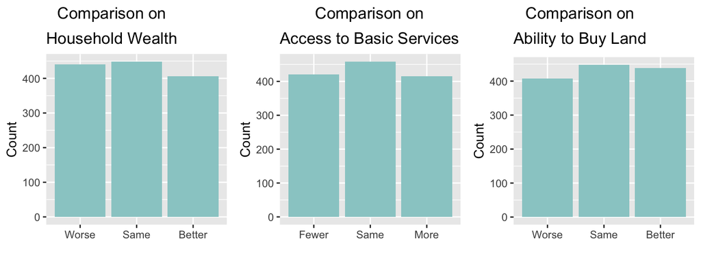

# 2. Hunger

At some point in the past 12 months, 48.42% of the participants have worried about having enough food, 50.77% have been unable to eat nutritious food, and 51.32% have only able to eat a few kinds of food.

Additionally, in the past 12 months, 49.36% of the participants had to skip a meal, 49.83% ate less than they should, and 50% ran out of food, all because they did not have enough money.

Finally, in the past 12 months, 52.24% of the participants were hungry at some point but did not eat and 50.9% went hungry for an entire day.

## Comparison to other Households

When asked to compare their household’s amount of food to eat to other households in the community 32% said they had less food to eat than most households, 34% said they had about the same amount of food to eat as most households, and 34% said they had more food to eat than most households.

When asked to compare the health of the children in their household to that of other children, 23% of participants said that their children were less healthy than children in other households, 21% said that their children were about as healthy as children in other households, and 21% said that their children were more healthy than children in other households.

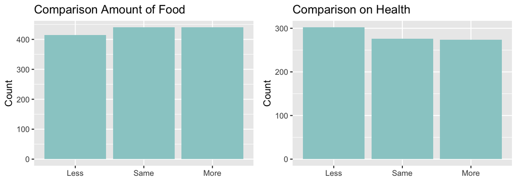

# 3. Healthy Lives

## Fertility and Maternal Health

In the past 12 months, 47.75% of all participants have given birth, and 48.28% of 15-19 year olds have given birth. 12.67% of women who gave birth had the birth attended by skilled staff.

## Diseases

In the sample, and 48.97% of participants had someone in their household been affected with a disease in the last 12 months.The following are the proportions for specific diseases:

1. HIV - 221.79 out of 1000 have HIV.
2. Tuberculosis - 199.38 out of 1000 have tuberculosis.
3. Malaria - 224.88 out of 1000 have malaria.
4. Hepatitis B - 221.79 out of 1000 have Hepatitis B.

## Other Diseases

1. Buruli ulcer - 119.78 out of 1000 have Buruli ulcer.
2. Chagas disease - 123.65 out of 1000 have Chagas disease.
3. Dengue and Chikungunya - 126.74 out of 1000 have Dengue and Chikungunya.
4. Dracunculiasis (guinea-worm disease) - 122.1 out of 1000 have Dracunculiasis (guinea-worm disease).
5. Echinococcosis - 123.65 out of 1000 have Echinococcosis.
6. Foodborne trematodiases - 122.1 out of 1000 have Foodborne trematodiases.
7. Human African trypanosomiasis (sleeping sickness) - 0 out of 1000 have Human African trypanosomiasis (sleeping sickness).
8. Leishmaniasis - 122.1 out of 1000 have Leishmaniasis.
9. Leprosy (Hansen’s disease) - 122.87 out of 1000 have Leprosy (Hansen’s disease).
10. Lymphatic filariasis - 130.6 out of 1000 have Lymphatic filariasis.
11. Mycetoma, chromoblastomycosis and other deep mycoses - 125.19 out of 1000 have Mycetoma, chromoblastomycosis and other deep mycoses.
12. Onchocerciasis (river blindness) - 132.15 out of 1000 have Onchocerciasis (river blindness).
13. Rabies -128.28 out of 1000 have Rabies.
14. Scabies and other ectoparasites -120.56 out of 1000 have cabies and other ectoparasites.
15. Schistosomiasis -125.97 out of 1000 have Schistosomiasis.
16. Soil-transmitted helminthiases -12.98 out of 1000 have Soil-transmitted helminthiases.
17. Snakebite envenoming -12.83 out of 1000 have Snakebite envenoming.
18. Taeniasis/Cysticercosis -12.6 out of 1000 have Taeniasis/Cysticercosis.
19. Trachoma -12.13 out of 1000 have Trachoma.
20. Yaws (Endemic treponematoses) -12.13 out of 1000 have Yaws (Endemic treponematoses).

## Health Care Access

Regarding health care access, 47.99% of the partcipants know of access to substance abuse treatment, 51.23% have access to health coverage, and 32.84% have current health insurance.

52.46% can afford the medicine their family needs, 52.46% can provide medicine when their family needs it, and 50.06% has an access to prescription medicines.

Additionally, 51.11% of the participants have access to vaccinations, 47.63% can afford vaccinations, and 31.53% have received vaccinations.

## Comparison to other Households

When asked to compare the health of the women in their household to that of other women in their community, 35% said that women in their household were less healthy than other women, 32% said that women in their household were about as healthy as other women, and 30% said that women in their household were more healthy than other women.

When asked to compare their household’s support needed for a healthy birth to other households in the community 5% said they had less support needed for a healthy birth than most households, 5% said they had about the same support needed for a healthy birth as most households, and 6% said they had better support needed for a healthy birth than most households.

When asked to compare the newborns in their household to newborns in other households in the community 32% said that newborns in their household were less healthy than other newborns, 34% said that newborns in their household were about the same level of health as other newborns, and 34% said that newborns in their household were more healthy than other newborns.

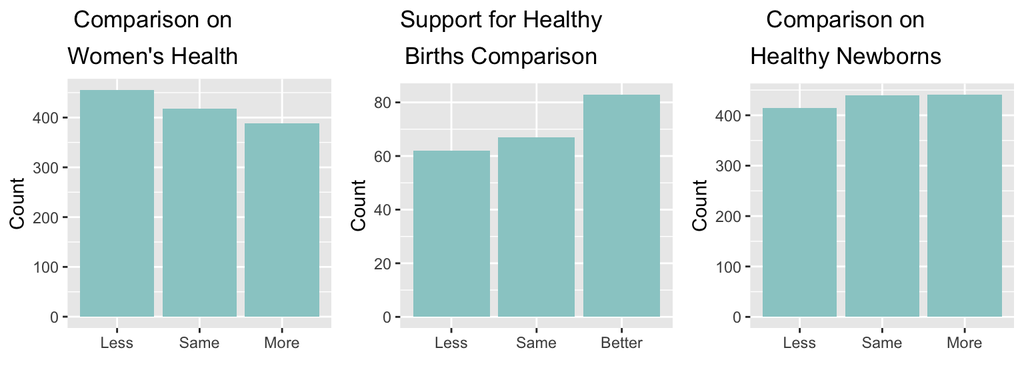

# 4. Quality Education

# Education

91.7% of respondents have at least some some grade school completed (91.4% of men and 92.1% of women).

When asked to compare the most educated person in their household to other members of the community, 31% said they had less education than members of the community, 35% said they had about the same amount of education as most households, and 34% said they had more formal education than others.

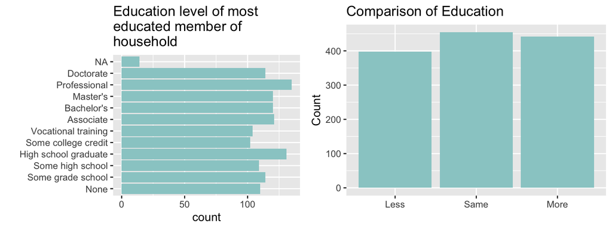

100% of all the participants have participated in education or vocational training in the past 12 months. 100% of men in the sample have participated and 100% of women in the sample have participated.

Of the women in the sample, 73.9% are or were enrolled in college, university, or trade school, 75.6% are or were enrolled in technical or vocational training, and 74.5% are or were enrolled in grade school.

Of the men in the sample, 77.2% are or were enrolled in college, university, or trade school, 73.9% are or were enrolled in technical or vocational training (TVET), and 72.9% are or were enrolled in grade school.

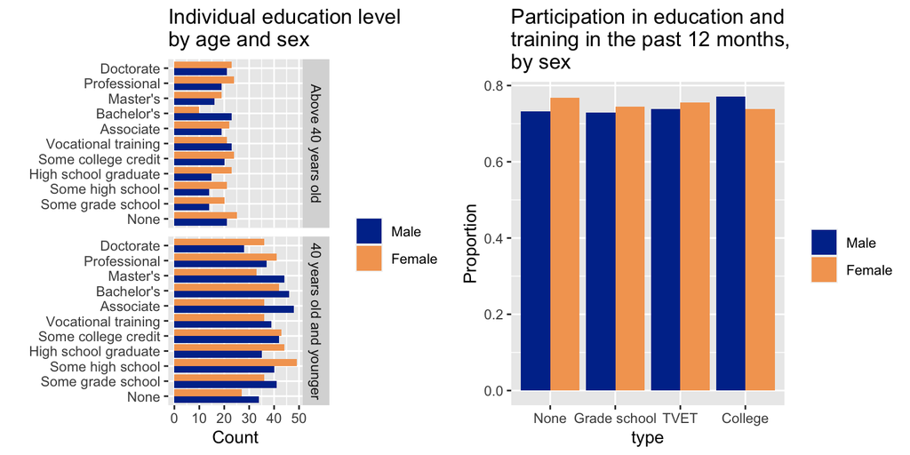

## Computer Activities

Of the following nine computer skills, the average number that each household possesses is 5.4 skills.

- 60.2% of respondents live with someone able to copy or move a file or folder.
- 61.1% of respondents live with someone able to use copy and paste tools to duplicate or move information within a document.
- 61.1% of respondents live with someone able to send e-mails with attached files (e.g. document, picture, video).
- 58.3% of respondents live with someone able to use basic arithmetic formulae in a spreadsheet.
- 60.1% of respondents live with someone able to connect and install new devices (e.g. a modem, camera, printer).
- 60.7% of respondents live with someone able to find, download, install, and configure software.
- 58.9% of respondents live with someone able to create electronic presentations with presentation software (including text, images, sound, video or charts).
- 60.7% of respondents live with someone able to transfer files between a computer and other devices.
- 60.6% of respondents live with someone able to Writing a computer program using a specialized programming language.

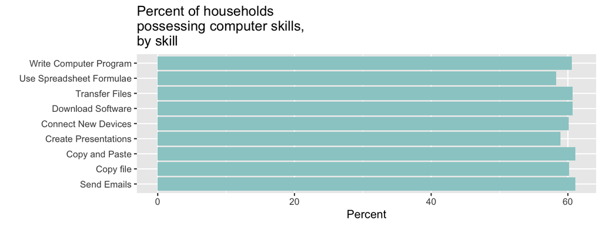

When asked to compare their household’s technology skills to those of other members of the community, 33% said they had fewer technology skills than other households, 33% said they had about the about the same amount of technology skills as other households, and 34% said they had more technology skills than other households.

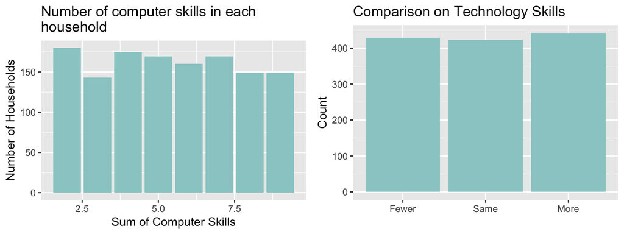

# 5. Gender Equality

51.1% of respondents in the sample are married or joined in a union. 50.9% of respondents own a mobile phone (52% of men and 49.9% of women). Of those with a mobile phone, 48.9% have internet access through their mobile phone.

## Unpaid labor and leadership

98.7% of households have a woman in a management position.

The average amount of unpaid labor per week (such as caregiving, cleaning, errands for the household, and home maintenance) is 73.9 (72.7 for men; 75 for women). The difference between men and women’s hours of unpaid labor is not statistically significant.

### Amount of unpaid labor compared to other women and men in community

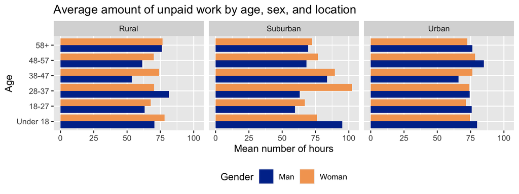

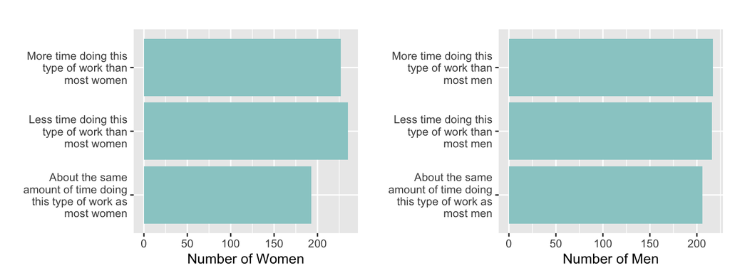

## Physical, Sexual, and Psychological Violence

In the last 12 months, 100% of married female respondents 15 years and older reported that a household member had been a victim of physical, sexual, or psychological violence.

[figure not shown]

47.7% of respondents with women in their household indicate that any women or girls in their household have undergone female genital mutilation or cutting. Of the households who have women that have undergone genital mutilation, the average number of women who have experienced this is 47. 34.3% of respondents with women in their household believe that their household has a higher percentage of women who have experienced female genital mutilation or cutting than most households, 34.2% believe their household is about the same as other households, and 31.5% believe their household has a lower rate of female genital mutilation or cutting than most households.

## Land ownership

33.6% of female respondents or respondents who reside with a woman feel that the women in their household own about the same amount of property or land as most women in other households within their community, 34% feel women in their household own less, and 32.4% feel women in their household own more.

Among households in which a woman resides, 99.2% have at least one woman who owns agricultural land. Among households in which at least one woman owns agricultural land, the average number of women who own agrictultural land is 50.7498002.

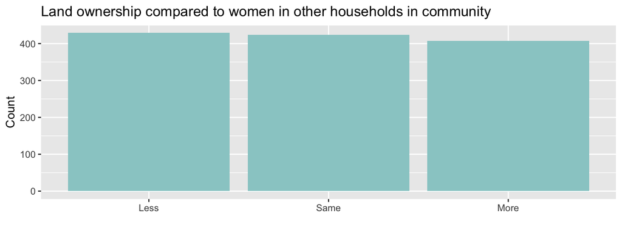

## Reproductive Health and Decision Making

50.3% of respondents know of services that can help them regarding decisions of their sexual relations including contraceptive use and reproductive health. Of those respondents who know of services, 33.8% have access to those services.

19.9% of women aged 15-49 always feel like they are in control of decisions regarding their sexual relations including contraceptive use and reproductive health.

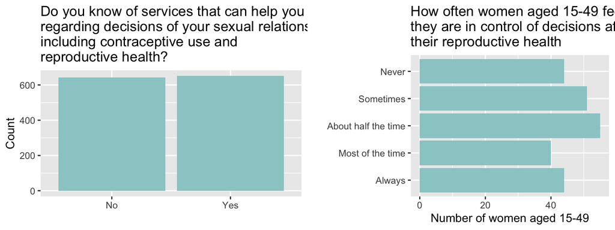

Women are most likely to report having less control over decisions affecting their reproductive health compared to most women .

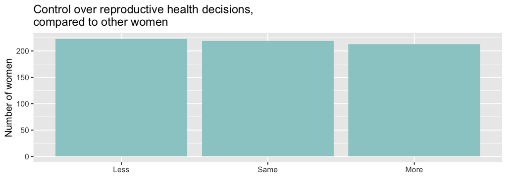

# 6. Clean Water and Sanitation

When asked about how frequently a household member had to drink water they felt was unsafe 20% said never, 21% said rarely (1-2 times in the prior 4 weeks), 20% said sometimes (3-10 times in the prior 4 weeks), 18% said often (11-20 times in the prior 4 weeks), and 21% said always (above 20 times in prior 4 weeks).

When asked about what water sources they had access to, participants responded that they have access to various sources in the following proportions:

- 58% of participants said they had access to piped water into their dwelling, yard or plot.
- 60% said they had access to public taps or standpipes.
- 78% said they had access to boreholes, tubewells, or a protected dug well.
- 76% said they had access to a protected or unprotected spring.
- 78% said they had access to rainwater collection or surface water.
- 77% said they had access to a cart with tank or tanker-truck.
- 58% said they had access to another water source.

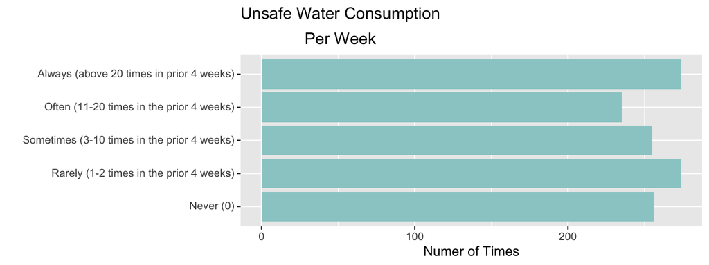

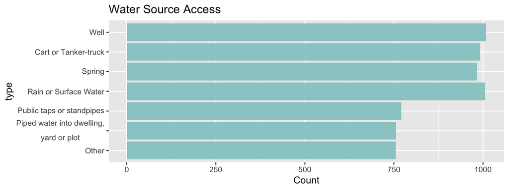

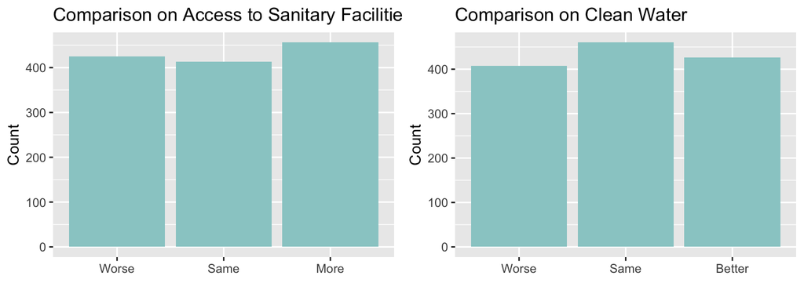

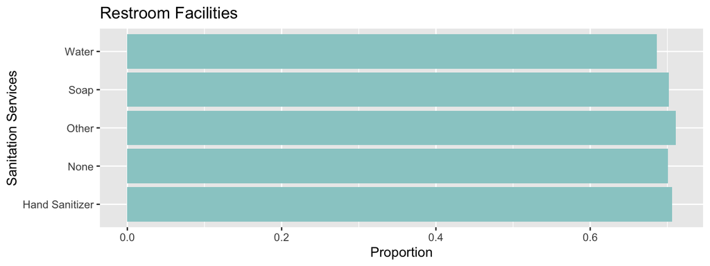

# 7. Affordable and Clean Energy

Of those who reported having access to electricity 277.43 people out of 1000 had access to a national grid connection, 288.25 people out of 1000 had access to a local mini grid connection, 288.25 people out of 1000 had access to an electric generator, 288.25 people out of 1000 had access to a rechargable battery, 282.07 people out of 1000 had access to a dry-cell battery, 276.66 people out of 1000 had access to a solar lantern, 283.62 people out of 1000 had access to a solar multi-light product, 282.84 people out of 1000 had a solar home system, 287.48 people out of 1000 had access to pico-hydro electricity, and 0 people out of 1000 responded that they don’t know, and 281.3 people out of 1000 responded “Other”.

When asked about primary fuel source for cooking 20% of participants said traditional (such as dung, agricultural residue, and fuelwood), 19% said intermediate (such as charcoal and kerosene), and 21% said modern (such as LPG, Biogas, ethanol gas, plant oils, dimethyl ether (DME), and electricity).

When asked about primary fuel source for heating 21% of participants said traditional (such as dung, agricultural residue, and fuelwood), 20% said intermediate (such as charcoal and kerosene), and 18% said modern (such as LPG, Biogas, ethanol gas, plant oils, dimethyl ether (DME), and electricity).

When asked about primary fuel source lighting 20% of participants said traditional (such as dung, agricultural residue, and fuelwood), 19% said intermediate (such as charcoal and kerosene), and 20% said modern (such as LPG, Biogas, ethanol gas, plant oils, dimethyl ether (DME), and electricity).

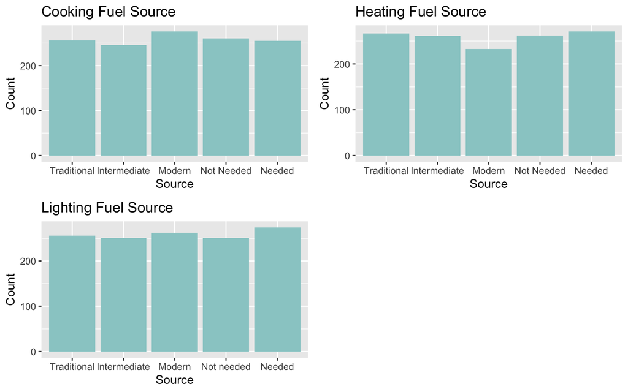

Of those who have access to electricity 12% use electricity mainly for appliances (includes refrigerator, dishwasher, clothes washer and dryer), 8% mainly use it for cooking, 31% mainly use it for entertainment and electronics (includes external power adapters, TVs, home office equipment, computers, and small appliances), 19% mainly use it for heating, and 31% mainly use it for lighting.

On average families use electricity 12 hours a day. Households also on average lose electricty 50 times a week. The average length of a power outage is 51 hours.

When asked to compare thier home’s access to electricity to other households in the community 34% said they had a home with worse access to electricity than most households, 33% said they had a home with about the same access to electricity as most households, and 33% said they had a home with better access to electricity than most households.

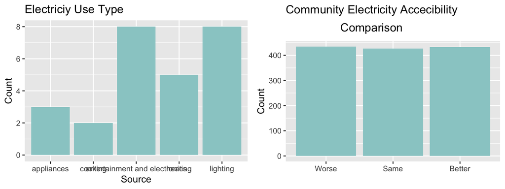

# 8. Decent Work and Economic Growth

## Hourly Wage Differences

Females make on average $13 an hour in local organizations, $13 if self-employed, $13 in multinational organizations, and $12 in government organizations. Males make on average $13 an hour in local organizations, $13 if self-employed, $12 in multinational organizations, and $12 in government organizations. However, the difference in hourly wage between men and women is not significant.

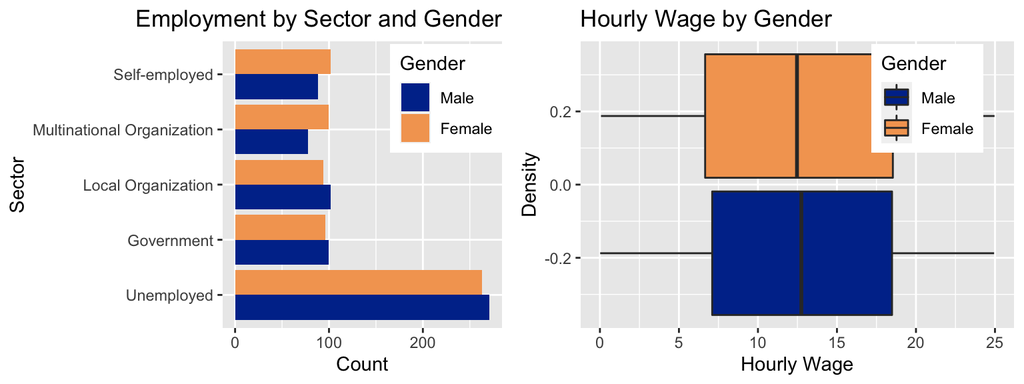

Females that are disabled make on average $12 an hour, while those who are not make $13. However, the difference in hourly wage between women that are and are not disabled is not significant. Men that are disabled make on average $12 an hour while those who are not make $13.However, the difference in hourly wage between men that are and are not disabled is not significant.

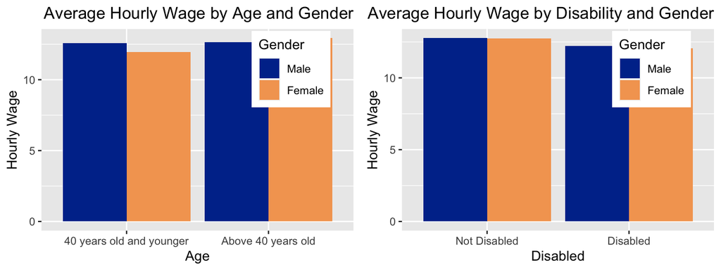

## Workplace Safety and Household Injuries

Of all participants 33% were in households where someone was injured within the last twelve months. 33.18% of men and 33.13% of women were in households where someone was injured in the last twelve months. However, the difference in household injuries between men and women is not significant.``

## Access to Banking and Finacial Services

Of all participants above the age of 15, 100% have access to a bank, mobile money account, banking/Micro finance account, or loans. 33% have had someone in their household within the past 12 months that made a financial transaction using a mobile phone.

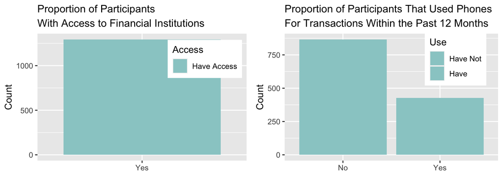

Participants were asked to compare one member of their household with other members of the community in regards to hazardous jobs. When asked to make this comparison, 34% said the member of their household had less hazardous working conditions than others in the community, 34% said the member of their household had working conditions that were about as hazardous as others in the community, and 32% said the member of their household had more hazardous working conditions than others in the community.

When asked to compare their household’s access to financial services to other households in the community 36% said they had worse access to financial services than most households, 33% said they had about the same access to financial services as most households, and 31% said they had better access to financial services than most households.

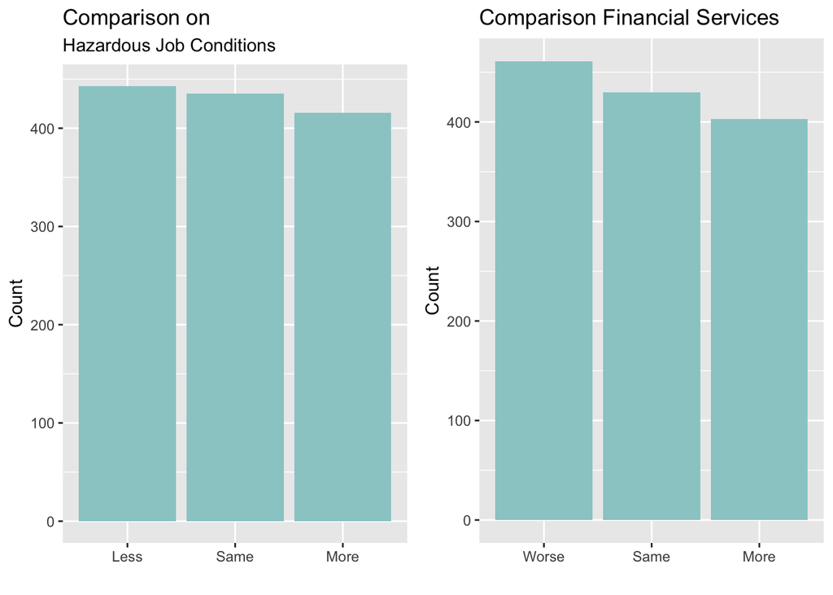

# 9. Reduced Inequalities

When asked to compare thier home to other households in the community 33% said they had a home less nice than most homes, 35% said they had a home about the same as most homes, and 32% said they had a home nicer than most homes.

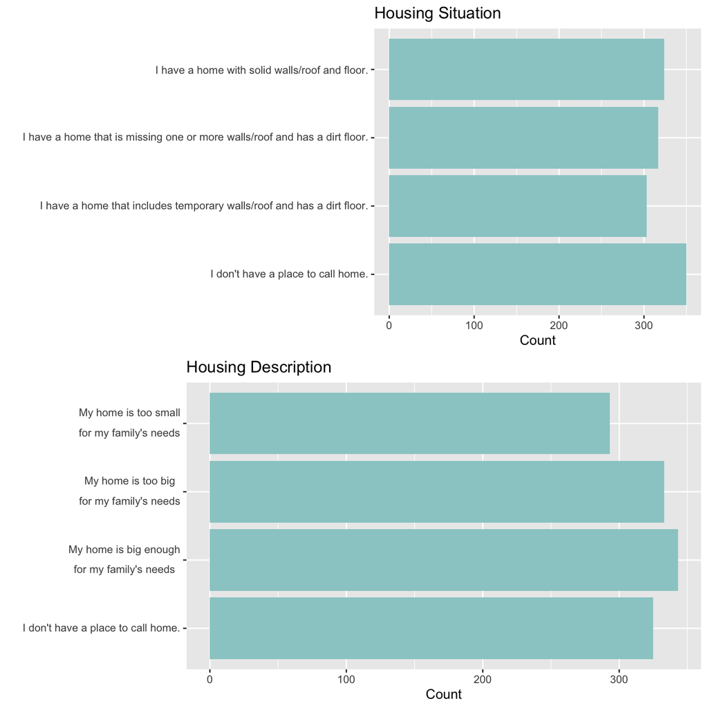

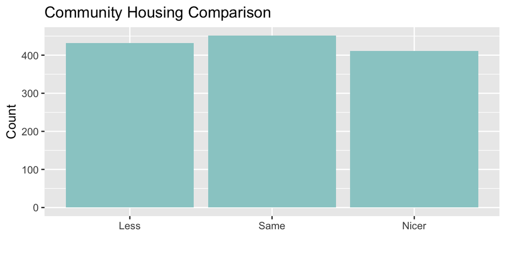